# Conclusions

## Overview of Project Conclusions

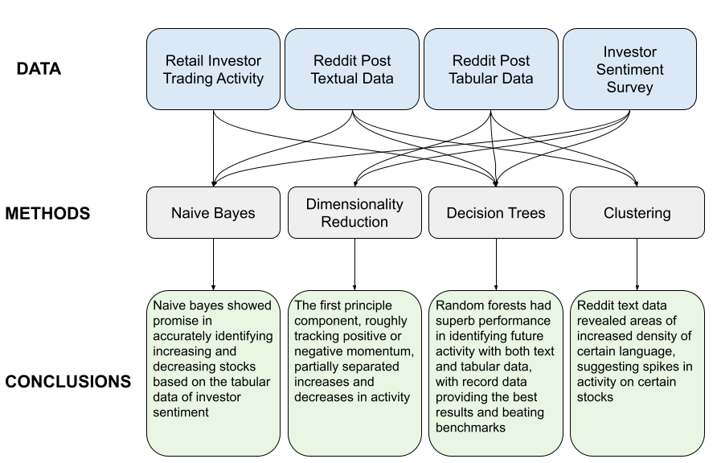

From the beggining, it proved difficult to gather a breadth of high quality data concerning retail investor trading activity. Even after finding a workable dataset to provide the studied outcome variable, in the Nasdaq data, social media data was elusive. After gathering a passable subset of Reddit posts and a backlog of investor sentiment surveys, it was unclear at the onset of the project if enough meaningful information would be contained in these variables to predict as complicated a phenomena as individual investors’ trading patters. While no one model provided the whole picture, across the four methods studied this project was able to piece together a picture of how investor sentiment online transfers into differences in observed activity and trading patters. Naive Bayes models revealed that information was contained in the Reddit posts’ texts, especially in the 10,000 most popular words in use in the corpus. While the accuracy of the models did not surpass the baseline, the Naive Bayes models which used only textual data were able to obtain a similar accuracy to the models that used only the more traditional, tabular data. Conversely, the dimensionality reduction methods showed that the tabular data contained some extremely significant information. In particular, Principle Component Analysis created a new dimension, which was a combination of the tabular dataset, that valenced each predictor based on whether it corresponded to positive or negative sentiment around a stock. In this case, the negative sentiment was particularly powerful, but across both positive and negative sentiment the new dimension provided a noticeable separation between stocks that would go on to increase or decrease in activity. This means that survey data was indeed a relevant predictor of activity, as were overall stock prices, tabular variables extracted from Reddit such as the comment number, and Nasdaq recorded investor sentiment.

Synthesizing dimensionality reduction and naive bayes, decision trees demonstrated that meaningful accuracy in predicting increasing and decreasing activity was possible when drawing on both datasets. By using both textual and tabular data, the random forests models showed that enough information was contained in the online discourse of retail investors to make substantive predictions about their future trading activity. All of the decision tree models performed strongly here, indicating the data itself may be of good quality for such analysis regardless of the particular structure of the decision tree in question.

Finally, outside of these two mdoels, clustering illuminated new structure within the dataset itself. While traditional clustering methods such as K means did not bear fruit, density based clustering was able to identify dense periods in the usuage of certain words over time. These clusters might correspond to the percieved “bandwagoning” effect that is attributed to individual investor forums online, where discussion of particular stocks grows sharply and leads to massive influxes of activity. Future work might start with attempting to better delineate and define these language clusters, such that they could be compared to outcome variables other than activity itself (which did not appear related in this project).

In the end, I believe these findings lend support to the idea that retail investors can be influenced by posts and sentiment online, and that this influence is refelcted in their trading behaviors. In conjuction with the finding of clustering in online posts, this project intensifies the notion that retail trading is tempestuous and volatile. Given its importance to financial markets and everyday lives, this makes retail trading worthy of future study, so as to better explain the volatility it introduces into the economy.

## Answering the Research Questions

[output not shown]